# Introduction

Customer churn is when a customer stops using a company’s service, a major challenge in the telecom industry. Retaining customers is critical because acquiring a new customer often costs significantly more than keeping an existing one. High churn rates can directly impact revenue, market share, and long-term profitability, making churn analysis an essential part of business strategy.

This project focuses on analyzing a telecom customer dataset to better understand the factors that influence churn. The dataset contains information about customer demographics, services subscribed to, contract types, payment methods, and whether the customer ultimately churned. Data cleaning, exploratory data analysis, and visualization, uncovers meaningful patterns and trends related to customer behavior.

The key objectives of this analysis are to:

- Identify major drivers of churn in the telecom dataset.
- Explore the relationships between services, contracts, payment methods, and churn.
- Provide actionable insights that could inform retention strategies.

The report is organized into the following sections:

1. **Methodology** – Outlines the data cleaning and analytical approach.
2. **Analysis** – Presents the findings from exploratory data analysis.
3. **Insights** – Summarizes the key takeaways from the analysis.
4. **Recommendations** – Suggests potential business strategies to reduce churn.
5. **Conclusions** – Provides a final summary of findings and their implications.

# Methodology

To ensure the dataset was reliable and ready for analysis, the project followed a structured methodology consisting of two main stages: data cleaning and exploratory data analysis.

## 1. Data Cleaning

Data cleaning was performed to prepare the dataset for accurate analysis. The key steps included:

- **Handling missing values**: Identified and addressed null or inconsistent entries.
- **Data type adjustments**: Converted columns (e.g., categorical and numerical features) into appropriate formats for analysis.
- **Feature engineering**: Created new variables where relevant (e.g., total number of services, AutoPay indicator) to capture additional customer behavior insights.
- **Standardization of categorical values**: Ensured consistent labeling across service and contract features.

## 2. Exploratory Data Analysis

EDA was conducted to uncover initial patterns, distributions, and relationships within the data. This included:

- **Descriptive statistics**: Summarized numerical and categorical features to understand customer demographics and service usage.
- **Churn distribution**: Examined the overall churn rate and compared it across different customer groups.
- **Service usage patterns**: Analyzed how the number and type of subscribed services correlated with churn.
- **Contract and payment analysis**: Investigated churn rates by contract type, payment method, and AutoPay status.
- **Visualizations**: Employed bar charts and churn rate comparisons to highlight significant trends.

This systematic approach ensured that the dataset was clean, reliable, and ready for extracting meaningful insights into customer churn behavior.

# Analysis

The exploratory data analysis revealed several important patterns in customer churn behavior:

## 1. Overall Churn Rate and identifying at at-risk group

- The dataset shows that approximately **26.54% of customers churned**.
- The churn rate by gender was very similar.
- About 24% of non-senior citizens left, but about 42% of senior citizens did leave.

```python
import pickle

with open('TelcoChurn_cleaned.pkl', 'rb') as file:
    data = pickle.load(file)

# Check and/or for partner and dependents
data.groupby(['Partner', 'Dependents'])['Churn'].mean() * 100
```

```
Partner  Dependents
0        0             34.237805
         1             21.329640
1        0             25.408348
         1             14.236707
Name: Churn, dtype: float64
```

- No partner and no dependents has a churn rate of 34.2%
- No partner but has dependents has a churn rate of 21.3%
- Partner but no dependents has a churn rate of 25.4%
- Partner with dependents has a churn rate of 14.2%
- More members in the household leads to a lower churn rate.
- Single people have the highest churn rate.
- Since the senior citizens and singles with no dependents have the highest churn rates so far, determine how many of the singles are senior citizens.

```python
senior_single_nodep = data[
    (data['SeniorCitizen'] == 1) &
    (data['Partner'] == 0) &
    (data['Dependents'] == 0)
]

print("Number of senior citizens who are single with no dependents:", len(senior_single_nodep))

churn_rate = senior_single_nodep['Churn'].mean() * 100
print(f"Churn rate: {churn_rate:.2f}%")
```

```
Number of senior citizens who are single with no dependents: 561
Churn rate: 49.20%
```

- This highlights that churn is a significant issue for this group: senior citizens with no partner or dependents.

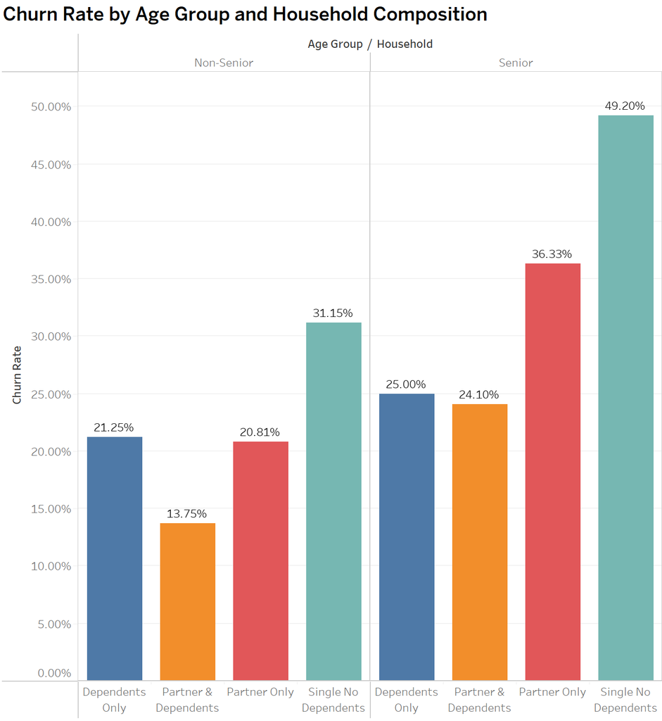

```python
from IPython.display import Image
Image("html/Screenshot2025-09-03141928.png")
```

## 2. Contract Types

- **Month-to-month contracts** had the highest churn rate, indicating that customers without long-term commitments are more likely to leave.
- **One-year and two-year contracts** showed significantly lower churn rates, reflecting the stabilizing effect of long-term agreements.

```python
data.groupby('Contract')['Churn'].mean() * 100
```

```
Contract
Month-to-month    42.709677
One year          11.269518
Two year           2.831858
Name: Churn, dtype: float64
```

```python
# Determine what kinds of contracts the identified group gets
summary = (
    senior_single_nodep
    .groupby("Contract")
    .agg(
        Customers=("Churn", "count"),
        ChurnRate=("Churn", "mean"),
        AvgRevenue=("AvgMonthlyRevenue", "mean"),
        tenure=("tenure","mean")
    )
)

# Convert churn rate to percentage
summary["ChurnRate"] = summary["ChurnRate"] * 100

print(summary)
```

```
                Customers  ChurnRate  AvgRevenue     tenure
Contract
Month-to-month        454  58.149780   76.438981  18.292952
One year               65  16.923077   80.155943  48.969231
Two year               42   2.380952   75.133692  62.119048
```

- An overwhelming majority of the identified group retain a month-to-month contract.
- The month-to-month contract is not necessarily more expensive.
- The month-to-month customers left quicker on average.

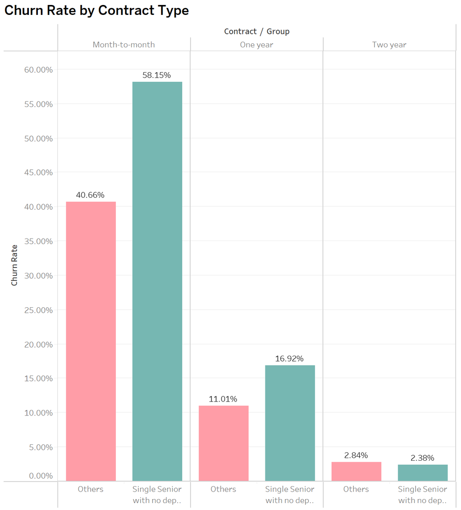

```python
Image("html/Screenshot2025-09-03142805.png")
```

## 3. Services and Usage Patterns

- Customers with **fewer subscribed services** were more prone to churn. In contrast, customers subscribed to multiple services (e.g., internet + streaming + phone) had higher retention rates.
- Certain optional services, such as **Tech Support** and **Online Security**, appeared to reduce churn when adopted, likely because they increase customer reliance on the provider.
- First, look at the difference in average monthly payment for the identified group versus everyone else.

```python
print("Average monthly revenue (mean) GROUP:", senior_single_nodep['AvgMonthlyRevenue'].mean())
print("Median monthly revenue GROUP:", senior_single_nodep['AvgMonthlyRevenue'].median())
```

```
Average monthly revenue (mean) GROUP: 76.7719230040956
Median monthly revenue GROUP: 79.47272727272728
```

```python
others = data[
    ~((data['SeniorCitizen'] == 1) &
      (data['Partner'] == 0) &
      (data['Dependents'] == 0))
]
print("Average monthly revenue (mean) OTHERS:", others['AvgMonthlyRevenue'].mean())
print("Median monthly revenue OTHERS:", others['AvgMonthlyRevenue'].median())
```

```
Average monthly revenue (mean) OTHERS: 63.723557168445474
Median monthly revenue OTHERS: 69.3204365079365
```

- The identified group has a higher monthly payment on average.
- To further explore why their payment is higher on average, look at the subscribed services of this group versus everyone else.

```python
import pandas as pd
services = [
    "PhoneService","OnlineSecurity", "OnlineBackup", "DeviceProtection",
    "TechSupport", "StreamingTV", "StreamingMovies"
]

# % of customers with each service = 1
service_mix_target = senior_single_nodep[services].apply(lambda x: (x==1).mean()*100)
service_mix_others = others[services].apply(lambda x: (x==1).mean()*100)

service_comparison = pd.DataFrame({
    "Target Group %": service_mix_target,
    "Others %": service_mix_others
})

print(service_comparison)
```

```
                  Target Group %   Others %
PhoneService           90.552585  90.296205
OnlineSecurity         18.716578  29.527923
OnlineBackup           34.402852  34.495526
DeviceProtection       32.442068  34.557235
TechSupport            17.468806  30.021598
StreamingTV            45.811052  37.796976
StreamingMovies        45.989305  38.167232
```

- The target group buys entertainment services (StreamingTV/Movies) more often, which raises bills.
- Seniors without dependents might not value streaming as much long-term, leading to dissatisfaction with the high bills.
- The target group doesn’t buy security/support addons (lower-cost services).
- The target group is under-utilizing protective/support services (no tech help, no security), which could lead to frustration with the service.

```python
service_all = [
    "PhoneService","MultipleLines","InternetService",
    "OnlineSecurity","OnlineBackup","DeviceProtection",
    "TechSupport","StreamingTV","StreamingMovies"
]

# 2) Map 0/1/2-coded columns
maps = {
    "PhoneService":      {0:"No", 1:"Yes"},
    # MultipleLines:  is already strings
    # InternetService is already strings
    "OnlineSecurity":    {0:"No", 1:"Yes", 2:"No internet service"},
    "OnlineBackup":      {0:"No", 1:"Yes", 2:"No internet service"},
    "DeviceProtection":  {0:"No", 1:"Yes", 2:"No internet service"},
    "TechSupport":       {0:"No", 1:"Yes", 2:"No internet service"},
    "StreamingTV":       {0:"No", 1:"Yes", 2:"No internet service"},
    "StreamingMovies":   {0:"No", 1:"Yes", 2:"No internet service"},
}

# 3) Build a tidy table: Service | Level | Customers | ChurnRate%

rows = []
for col in service_all:
    s = data[col]
    if col in maps:
        s = s.map(maps[col]) # convert 0/1/2 -> strings
    s = s.astype("string").fillna("Unknown") # ensure strings everywhere

    tmp = (
        data.assign(_level=s)
          .groupby("_level", dropna=False)["Churn"]
          .agg(ChurnRate=lambda x: x.mean()*100, Customers="count")
          .reset_index()
          .rename(columns={"_level":"Level"})
    )
    tmp.insert(0, "Service", col)
    rows.append(tmp)

churn_by_service_long = pd.concat(rows, ignore_index=True)
churn_by_service_long.sort_values(["Service","Level"], inplace=True)

print(churn_by_service_long)
```

```
             Service                Level  ChurnRate  Customers
14  DeviceProtection                   No  39.127625       3095
15  DeviceProtection  No internet service   7.404980       1526
16  DeviceProtection                  Yes  22.502064       2422
5    InternetService                  DSL  18.959108       2421
6    InternetService          Fiber optic  41.892765       3096
7    InternetService                   No   7.404980       1526
2      MultipleLines                   No  25.044248       3390
3      MultipleLines     No phone service  24.926686        682
4      MultipleLines                  Yes  28.609896       2971
11      OnlineBackup                   No  39.928756       3088
12      OnlineBackup  No internet service   7.404980       1526
13      OnlineBackup                  Yes  21.531494       2429
8     OnlineSecurity                   No  41.766724       3498
9     OnlineSecurity  No internet service   7.404980       1526
10    OnlineSecurity                  Yes  14.611194       2019
0       PhoneService                   No  24.926686        682
1       PhoneService                  Yes  26.709637       6361
23   StreamingMovies                   No  33.680431       2785
24   StreamingMovies  No internet service   7.404980       1526
25   StreamingMovies                  Yes  29.941435       2732
20       StreamingTV                   No  33.523132       2810
21       StreamingTV  No internet service   7.404980       1526
22       StreamingTV                  Yes  30.070188       2707
17       TechSupport                   No  41.635474       3473
18       TechSupport  No internet service   7.404980       1526
19       TechSupport                  Yes  15.166341       2044
```

```python
len(senior_single_nodep)
```

```
561
```

```python
senior_services = senior_single_nodep[services].apply(pd.Series.value_counts)
print(senior_services)
```

```
   PhoneService  OnlineSecurity  OnlineBackup  DeviceProtection  TechSupport  \
0          53.0             431           343               354          438
1         508.0             105           193               182           98
2           NaN              25            25                25           25

   StreamingTV  StreamingMovies
0          279              278
1          257              258
2           25               25
```

- Only 105 out of 561 retain online security
- Only 98 out of 561 retain tech support

[figure not shown]

```python
Image("html/Screenshot2025-09-03143328.png")
```

## 4. Payment Methods and AutoPay

- Customers who paid via **electronic check** exhibited the highest churn rate, suggesting dissatisfaction with either the payment method or the customer segment using it.
- **AutoPay** customers churned at a much lower rate than those who paid manually, likely due to reduced friction in billing and stronger customer lock-in.

```python
summary2 = data.groupby('PaymentMethod').agg(
    Customers2=('Churn', 'count'),
    ChurnRate2=('Churn', 'mean'),
    AvgTenure2=('tenure', 'mean'),
    AvgMonthlyCharges2=('MonthlyCharges', 'mean'),
    AutoPayCount2=('IsAutoPay', 'sum')  # assumes IsAutoPay is 1 for autopay, 0 otherwise
)

# Convert churn rate to percentage
summary2['ChurnRate2'] = summary2['ChurnRate2'] * 100

# Optional: show AutoPay as % of customers
summary2['AutoPayPercent'] = summary2['AutoPayCount2'] / summary2['Customers2'] * 100

summary2 = summary2.sort_values('ChurnRate2', ascending=False)
summary2
```

| PaymentMethod | Customers2 | ChurnRate2 | AvgTenure2 | AvgMonthlyCharges2 | AutoPayCount2 | AutoPayPercent |
| --- | --- | --- | --- | --- | --- | --- |
| Electronic check | 2365 | 45.285412 | 25.174630 | 76.255814 | 0 | 0.0 |
| Mailed check | 1612 | 19.106700 | 21.830025 | 43.917060 | 0 | 0.0 |
| Bank transfer (automatic) | 1544 | 16.709845 | 43.656736 | 67.192649 | 1544 | 100.0 |
| Credit card (automatic) | 1522 | 15.243101 | 43.269382 | 66.512385 | 1522 | 100.0 |

- Electronic check stands out as having a higher churn rate.
- Electronic check is used most.

```python
data.groupby('IsAutoPay')['Churn'].mean() * 100
```

```
IsAutoPay
0    34.674378
1    15.981735
Name: Churn, dtype: float64
```

- Not using auto pay more than doubles the churn rate.

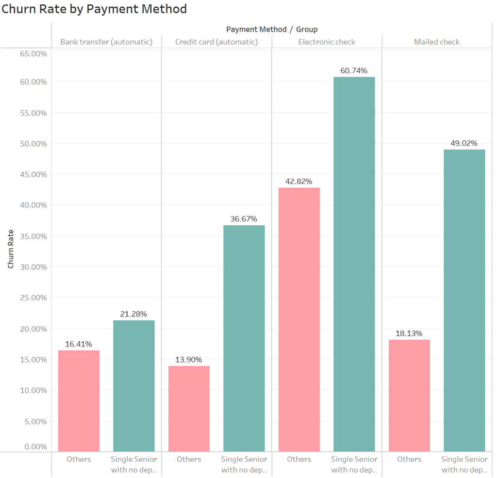

```python
Image("html/LASTSCREENSHOT.png")
```

# Insights

The analysis identified four primary drivers of churn in the telecom dataset:

1. **Demographics**  
   Senior citizens without dependents or partners have the highest churn rate, approaching 50%. This highlights that customer demographics play a significant role in retention, particularly for single senior households.
2. **Contract Type**  
   Customers on month-to-month contracts experience a churn rate of 43%. Among the targeted demographic group, 454 out of 561 used month-to-month contracts, underscoring the lack of long-term commitment as a critical factor in customer attrition.
3. **Value-Added Services (Online Security and Tech Support)**  
   Two optional services emerged as strong churn differentiators:
   - Customers without **Online Security** churn at a rate about 27% higher than those with it.
   - Customers without **Tech Support** churn about 26% more than those with it.
   - Only 105 out of 561 retain online security.
   - Only 98 out of 561 retain tech support.

   This shows that service engagement strongly influences retention among this targeted group.
4. **Payment Method and AutoPay**  
   Customers not enrolled in AutoPay churn at more than double the rate (35% vs. 16%). Payment method also matters: customers paying by electronic check have the highest churn rate at 45% and the highest adoption rate; None of these customers are enrolled in AutoPay. Billing convenience and method are, therefore, major churn drivers.

# Recommendations

Based on the identified churn drivers, the following strategies are recommended:

1. **Targeted Support for At-Risk Demographics**
   - Develop specialized retention programs for senior customers without dependents or partners, such as personalized customer service, simplified plan options, and loyalty rewards.
   - Provide tailored communication and outreach that builds trust and emphasizes reliability, which may resonate more strongly with this group.
2. **Promote Long-Term Contracts**
   - Incentivize customers to switch from month-to-month to one- or two-year contracts through discounts, bundled offers, or loyalty benefits.
   - Highlight the value of stability and potential cost savings in marketing campaigns to encourage longer commitments.
3. **Increase Adoption of Online Security and Tech Support**
   - Bundle Online Security and Tech Support with core services at a reduced cost to make them more attractive.
   - Educate customers on the benefits of these services, emphasizing protection, reliability, and peace of mind.
   - Target the specified group of customers specifically, since their adoption of these services is currently lowest.
4. **Encourage AutoPay Enrollment and Improve Payment Options**
   - Offer incentives such as discounts, reward points, or exclusive perks for customers who enroll in AutoPay.
   - Improve awareness of AutoPay benefits through customer communication.
   - Reduce reliance on electronic checks by encouraging digital payment methods (credit/debit cards, bank transfers) that integrate seamlessly with AutoPay.

Implementing these strategies can directly address the key drivers of churn. By focusing on customer demographics, contract structures, service adoption, and billing methods, the company can strengthen customer loyalty and significantly reduce churn.

# Conclusion

This project analyzed telecom customer data to identify the major drivers of churn and provide actionable strategies for retention. The analysis revealed four primary churn factors: customer demographics, contract type, adoption of value-added services, and billing/payment methods.

Key findings show that senior citizens without dependents or partners are at the highest risk of churn, especially when combined with month-to-month contracts and low adoption of support services. Additionally, reliance on electronic checks and lack of AutoPay enrollment strongly correlate with elevated churn rates.

These insights suggest that churn is not driven by a single factor but by an interplay of customer demographics, service engagement, and billing practices. Addressing these areas through targeted retention strategiesm such as promoting long-term contracts, incentivizing AutoPay, and increasing adoption of security and support services can significantly reduce churn.

Ultimately, by focusing on the needs of vulnerable customer segments and removing friction in service and payment experiences, the company can strengthen customer loyalty, improve profitability, and build a more resilient customer base.